# A3: Incarceration Trends in the U.S.

### 3.0 Racial Disparities in Prison Population in the U.S:

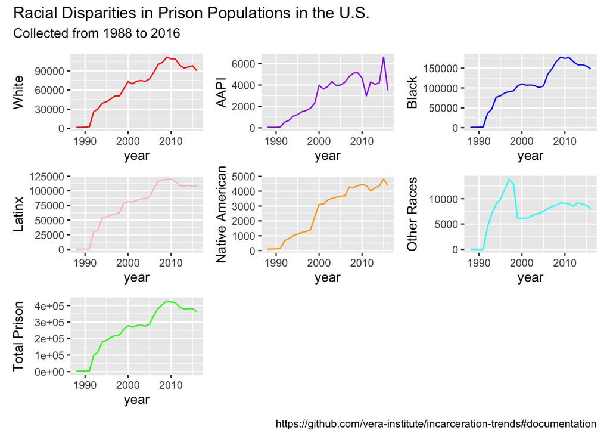

This trend chart compares prison population rate from 1988 to 2016 by race and reveals the scale of racial disparities in imprisonment in the U.S. This data visualization gives a staggering disparity among Black and Latino incarceration given the total incarcerations in the U.S. from 1988 to 2016.

### 4.0 Percentage of Minority Populations Incarcerated of Total Prison Population:

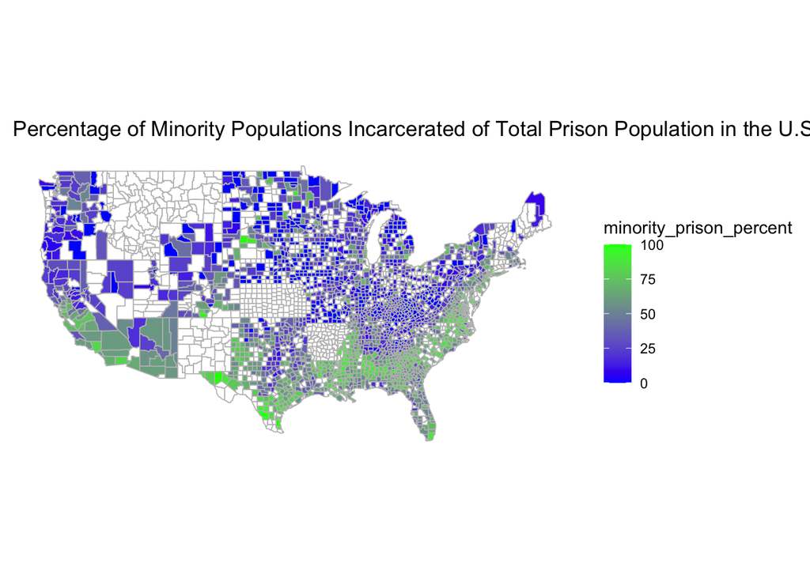

This map shows the percentage of minority incarcerations to the total incarceration in the U.S. This map geographically illustrates the racial and ethnic disparities of mass incarcerations for minority populations. This map shows how a majority of incarcerated individuals in California are BIPOC.

### 5.0 Summary:

These charts and maps underpin the widespread racial and ethnic disparities in incarceration rates and in the criminal justice system by revealing the disproportion of incarcerations of minority populations through data wrangling and visualization. This project emphasizes the need for criminal justice reform to end systemic deep-rooted racial and ethnic disparities.